# chapter6

Summary graphs

```r
n <- RATSL$Time %>% unique() %>% length()
RATSS <- RATSL %>%
  group_by(Group, Time) %>%
  summarise( mean = mean(Weight), se = sd(Weight)/sqrt(n) ) %>%
  ungroup()
glimpse(RATSS)
```

```
## Rows: 33
## Columns: 4
## $ Group <fct> 1, 1, 1, 1, 1, 1, 1, 1, 1, 1, 1, 2, 2, 2, 2, 2, 2, 2, 2, 2, 2...
## $ Time  <int> 1, 8, 15, 22, 29, 36, 43, 44, 50, 57, 64, 1, 8, 15, 22, 29, 3...
## $ mean  <dbl> 250.625, 255.000, 254.375, 261.875, 264.625, 265.000, 267.375...
## $ se    <dbl> 4.589478, 3.947710, 3.460116, 4.100800, 3.333956, 3.552939, 3...
```

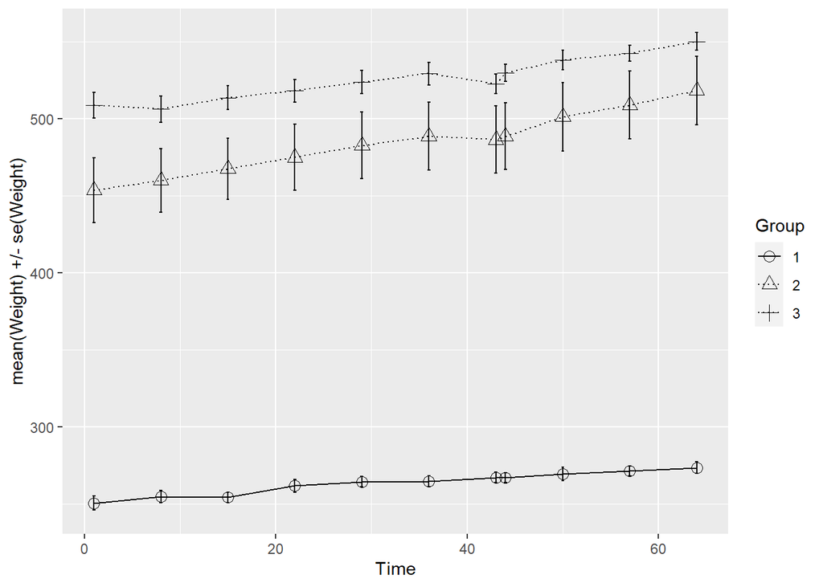

```r
ggplot(RATSS, aes(x = Time, y = mean, linetype = Group, shape = Group)) +
  geom_line() +
  scale_linetype_manual(values = c(1,3,3)) +
  geom_point(size=3) +
  scale_shape_manual(values = c(1,2,3)) +
  geom_errorbar(aes(ymin = mean - se, ymax = mean + se, linetype="1"), width=0.3) +
  scale_y_continuous(name = "mean(Weight) +/- se(Weight)")
```

Mean response profiles for the three groups in the RATS data. The mean weight of groups 2 and 3 grow similarly whereas in group 1 slower.

We will create a summary data by group and ID with mean as the summary variable (ignoring baseline Time 1).

```r
RATSLSS <- RATSL %>%
  filter(Time > 1) %>%
  group_by(Group, ID) %>%
  summarise( mean=mean(Weight) ) %>%
  ungroup()
```

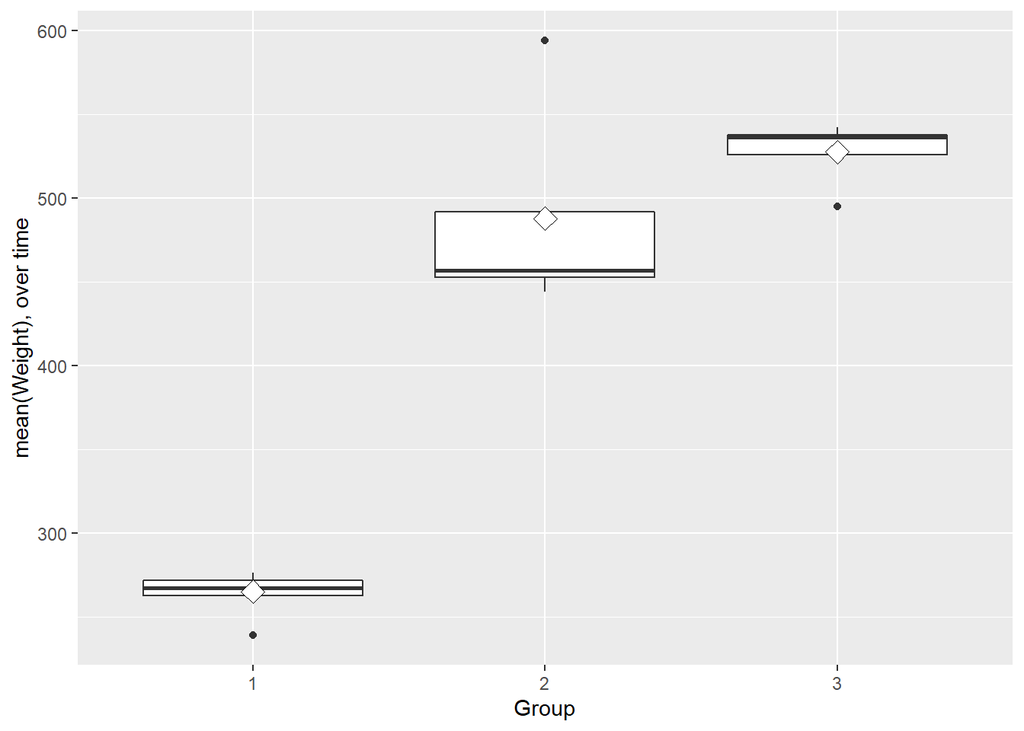

```r
ggplot(RATSLSS, aes(x = Group, y = mean)) +
  geom_boxplot() +
  stat_summary(fun.y = "mean", geom = "point", shape=23, size=4, fill = "white") +
  scale_y_continuous(name = "mean(Weight), over time")
```

Group 2 has the biggest difference on the weight over time. All the groups have an outlier. We will create a new dataset without these outliers.

```r
RATSLSS2 <- filter(RATSLSS, (Group==1 & mean > 250)|(Group==2 & mean < 550)| (Group==3 & mean > 500))

RATSLSS2
```

```
## # A tibble: 13 x 3
##    Group ID     mean
##    <fct> <fct> <dbl>
##  1 1     1      263.
##  2 1     3      262.
##  3 1     4      267.
##  4 1     5      271.
##  5 1     6      276.
##  6 1     7      275.
##  7 1     8      268.
##  8 2     9      444.
##  9 2     10     458.
## 10 2     11     456.
## 11 3     14     536.
## 12 3     15     542.
## 13 3     16     536.
```

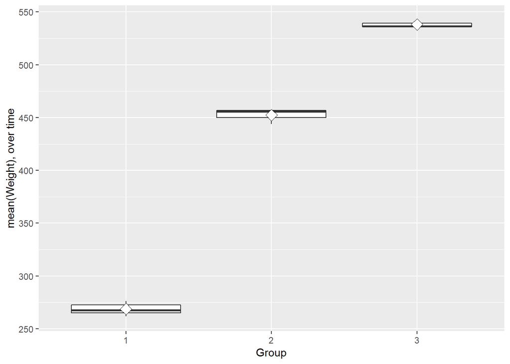

```r
ggplot(RATSLSS2, aes(x = Group, y = mean)) +
  geom_boxplot() +
  stat_summary(fun.y = "mean", geom = "point", shape=23, size=4, fill = "white") +
  scale_y_continuous(name = "mean(Weight), over time")
```

Three groups in a boxplot without outliers.

After seeing the graphs let’s compare the groups using a more formal way: t-test. Let choose groups 2 and 3 to see if they are similar or not.

```r
RATSLSS23 <- filter(RATSLSS2,(Group==2| Group==3))
RATSLSS23$Group <- factor(RATSLSS23$Group)
str(RATSLSS23)
```

```
## tibble [6 x 3] (S3: tbl_df/tbl/data.frame)
##  $ Group: Factor w/ 2 levels "2","3": 1 1 1 2 2 2
##  $ ID   : Factor w/ 16 levels "1","2","3","4",..: 9 10 11 14 15 16
##  $ mean : num [1:6] 444 458 456 536 542 ...
```

```r
t.test(mean ~ Group, data = RATSLSS23, var.equal = TRUE)
```

```
##
##  Two Sample t-test
##
## data:  mean by Group
## t = -18.235, df = 4, p-value = 5.32e-05
## alternative hypothesis: true difference in means is not equal to 0
## 95 percent confidence interval:
##  -98.94088 -72.79246
## sample estimates:
## mean in group 2 mean in group 3
##        452.4000        538.2667
```

```r
fit <- lm(mean ~ Group, data = RATSLSS2)
anova(fit)
```

```
## Analysis of Variance Table
##
## Response: mean
##           Df Sum Sq Mean Sq F value    Pr(>F)
## Group      2 176917   88458  2836.4 1.687e-14 ***
## Residuals 10    312      31
## ---
## Signif. codes:  0 '***' 0.001 '**' 0.01 '*' 0.05 '.' 0.1 ' ' 1
```

one-way analysis of variance (ANOVA). In one-way ANOVA, the data is organized into several groups base on one single grouping variable (also called factor variable).

ANOVA test hypotheses:

Null hypothesis: the means of the different groups are the same Alternative hypothesis: At least one sample mean is not equal to the others.

The model summary first lists the independent variables being tested in the model, in this example it is Group. All of the variation that is not explained by the independent variables is called residual variance and shown in Residuals line on the summary. The Df column displays the degrees of freedom for the independent variable Group to be 2 (the number of levels in the variable minus 1), and the residuals to be 10 (the total number of observations minus one and minus the number of levels in the independent variables). The Sum Sq column displays the sum of squares, the total variation between the group means and the overall mean. For the variable Group it is 176917 and for the residuals it is 312. The Mean Sq column is the mean of the sum of squares. It is calculated by dividing the sum of squares by the degrees of freedom for each parameter. For the varible Group it is 88458 and for the residuals 31. The F-value is the test statistic from the F test. This is the mean square of each independent variable divided by the mean square of the residuals. The larger the F value, the more likely it is that the variation caused by the independent variable is real and not due to chance. For the varible Group the value is 2836.4 showing that the variation caused by Group is real. The Pr(>F) is the p-value of the F-statistic. It shows how likely it is that the F-value calculated from the test would have occurred if the null hypothesis of no difference among group means were true. The p-value is very low (p < 0.001) so we can say that the Group has a real impact. Null hypothesis can be rejected.

Let’s start working on BPRSL dataset and ch 9. Linear Mixed Effects Models for Normal Response Variables Two examples of linear mixed effects models: the random intercept model and the random intercept and slope model.

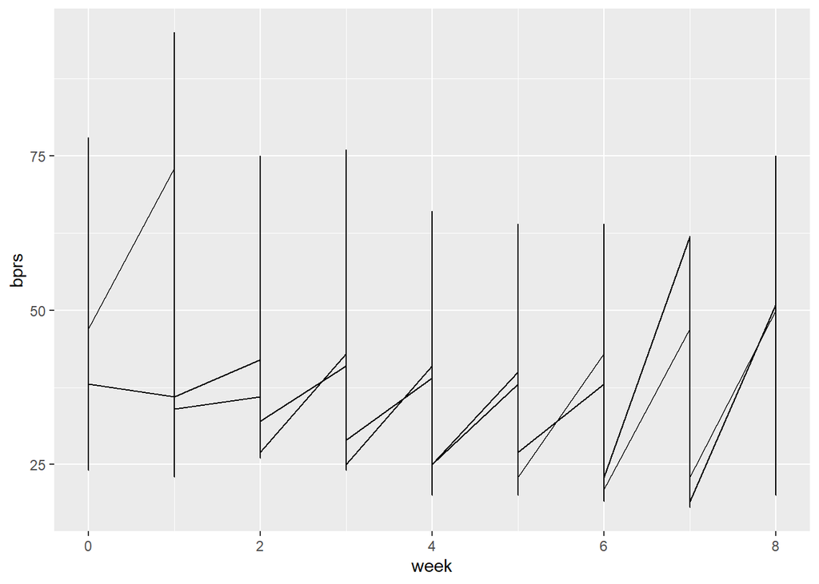

```r
ggplot(BPRSL, aes(x = week, y = bprs, group = treatment)) +
  geom_line()
```

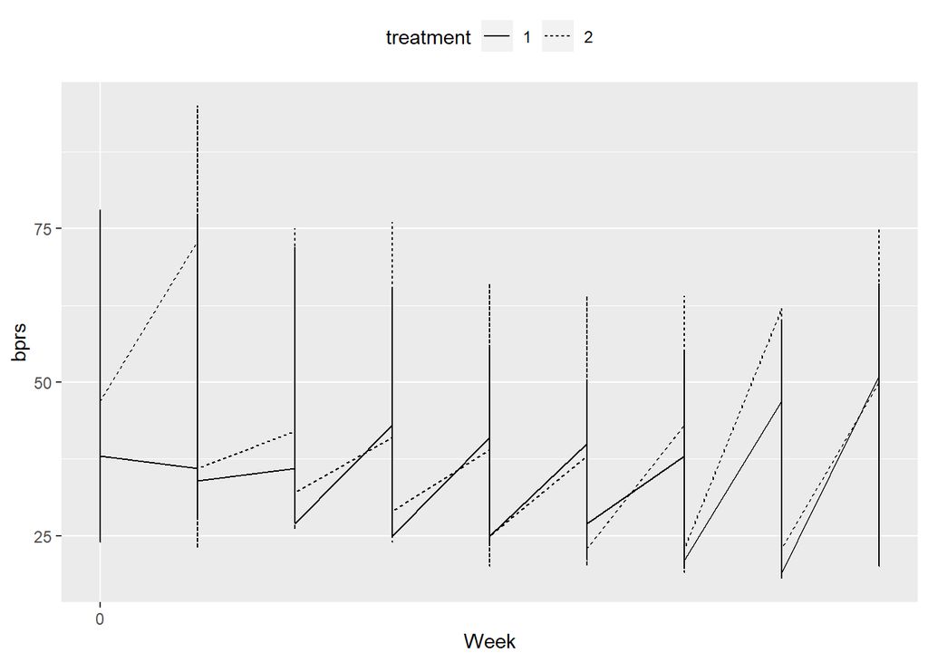

```r
ggplot(BPRSL, aes(x = week, y = bprs, group = treatment)) +
  geom_line(aes(linetype = treatment)) +
  scale_x_continuous(name = "Week", breaks = seq(0, 60, 10)) +
  scale_y_continuous(name = "bprs") +
  theme(legend.position = "top")
```

Create a regression model

```r
BPRSL_reg <- lm(bprs ~ week + treatment, data = BPRSL)
summary(BPRSL_reg)
```

```
##
## Call:
## lm(formula = bprs ~ week + treatment, data = BPRSL)
##
## Residuals:
##     Min      1Q  Median      3Q     Max
## -22.454  -8.965  -3.196   7.002  50.244
##
## Coefficients:
##             Estimate Std. Error t value Pr(>|t|)
## (Intercept)  46.4539     1.3670  33.982   <2e-16 ***
## week         -2.2704     0.2524  -8.995   <2e-16 ***
## treatment2    0.5722     1.3034   0.439    0.661
## ---
## Signif. codes:  0 '***' 0.001 '**' 0.01 '*' 0.05 '.' 0.1 ' ' 1
##
## Residual standard error: 12.37 on 357 degrees of freedom
## Multiple R-squared:  0.1851, Adjusted R-squared:  0.1806
## F-statistic: 40.55 on 2 and 357 DF,  p-value: < 2.2e-16
```

Residual Standard Error: Standard deviation of residuals / errors of the regression model. Multiple R-Squared (0.19): Percent of the variance of exam intact after subtracting the error of the model. Adjusted R-Squared (0.18): how well the model fits the data, i.e. the percentage of the dependent variable variation that the linear model explains (ranging between 0 and 1). The R-squared is quite low.

The Random Intercept Model

```r
library(lme4)
BPRSL_ref <- lmer(bprs ~ week + treatment + (1 | subject), data = BPRSL, REML = FALSE)
summary(BPRSL_ref)
```

```
## Linear mixed model fit by maximum likelihood  ['lmerMod']
## Formula: bprs ~ week + treatment + (1 | subject)
##    Data: BPRSL
##
##      AIC      BIC   logLik deviance df.resid
##   2748.7   2768.1  -1369.4   2738.7      355
##
## Scaled residuals:
##     Min      1Q  Median      3Q     Max
## -3.0481 -0.6749 -0.1361  0.4813  3.4855
##
## Random effects:
##  Groups   Name        Variance Std.Dev.
##  subject  (Intercept)  47.41    6.885
##  Residual             104.21   10.208
## Number of obs: 360, groups:  subject, 20
##
## Fixed effects:
##             Estimate Std. Error t value
## (Intercept)  46.4539     1.9090  24.334
## week         -2.2704     0.2084 -10.896
## treatment2    0.5722     1.0761   0.532
##
## Correlation of Fixed Effects:
##            (Intr) week
## week       -0.437
## treatment2 -0.282  0.000
```

T-value is now bigger for week than it was before.

Random Intercept and Random Slope Model

```r
BPRSL_ref1 <- lmer(bprs ~ week + treatment + (week | subject), data = BPRSL, REML = FALSE)
summary(BPRSL_ref1)
```

```
## Linear mixed model fit by maximum likelihood  ['lmerMod']
## Formula: bprs ~ week + treatment + (week | subject)
##    Data: BPRSL
##
##      AIC      BIC   logLik deviance df.resid
##   2745.4   2772.6  -1365.7   2731.4      353
##
## Scaled residuals:
##     Min      1Q  Median      3Q     Max
## -2.8919 -0.6194 -0.0691  0.5531  3.7976
##
## Random effects:
##  Groups   Name        Variance Std.Dev. Corr
##  subject  (Intercept) 64.8222  8.0512
##           week         0.9609  0.9802   -0.51
##  Residual             97.4305  9.8707
## Number of obs: 360, groups:  subject, 20
##
## Fixed effects:
##             Estimate Std. Error t value
## (Intercept)  46.4539     2.1052  22.066
## week         -2.2704     0.2977  -7.626
## treatment2    0.5722     1.0405   0.550
##
## Correlation of Fixed Effects:
##            (Intr) week
## week       -0.582
## treatment2 -0.247  0.000
```

```r
anova(BPRSL_ref1, BPRSL_ref)
```

```
## Data: BPRSL
## Models:
## BPRSL_ref: bprs ~ week + treatment + (1 | subject)
## BPRSL_ref1: bprs ~ week + treatment + (week | subject)
##            npar    AIC    BIC  logLik deviance  Chisq Df Pr(>Chisq)
## BPRSL_ref     5 2748.7 2768.1 -1369.4   2738.7
## BPRSL_ref1    7 2745.4 2772.6 -1365.7   2731.4 7.2721  2    0.02636 *
## ---
## Signif. codes:  0 '***' 0.001 '**' 0.01 '*' 0.05 '.' 0.1 ' ' 1
```

The Random Intercept Model:BPRSL_ref Random Intercept and Random Slope Model:BPRSL_ref1 Two-way ANOVA test hypotheses: BPRSL_ref1 is slightly better.

Significance is low.

Null hypothesis can be rejected.

Random Intercept and Random Slope Model with interaction

```r
BPRSL_ref2 <- lmer(bprs ~ week * treatment + (week | subject), data = BPRSL, REML = FALSE)
summary(BPRSL_ref2)
```

```
## Linear mixed model fit by maximum likelihood  ['lmerMod']
## Formula: bprs ~ week * treatment + (week | subject)
##    Data: BPRSL
##
##      AIC      BIC   logLik deviance df.resid
##   2744.3   2775.4  -1364.1   2728.3      352
##
## Scaled residuals:
##     Min      1Q  Median      3Q     Max
## -3.0512 -0.6271 -0.0768  0.5288  3.9260
##
## Random effects:
##  Groups   Name        Variance Std.Dev. Corr
##  subject  (Intercept) 64.9964  8.0620
##           week         0.9687  0.9842   -0.51
##  Residual             96.4707  9.8220
## Number of obs: 360, groups:  subject, 20
##
## Fixed effects:
##                 Estimate Std. Error t value
## (Intercept)      47.8856     2.2521  21.262
## week             -2.6283     0.3589  -7.323
## treatment2       -2.2911     1.9090  -1.200
## week:treatment2   0.7158     0.4010   1.785
##
## Correlation of Fixed Effects:
##             (Intr) week   trtmn2
## week        -0.650
## treatment2  -0.424  0.469
## wek:trtmnt2  0.356 -0.559 -0.840
```

The t-value for week is -7.32. Week has a t-value great enough to refute the 0-hypotheses. Based on the results, null hypotheses can be refute for week. It cannot be refute for treatments.

An ANOVA test on the two models Random Intercept and Random Slope Model: BPRSL_ref1 and Random Intercept and Random Slope Model with interaction: BPRSL_ref2

```r
anova(BPRSL_ref2, BPRSL_ref1)
```

```
## Data: BPRSL
## Models:
## BPRSL_ref1: bprs ~ week + treatment + (week | subject)
## BPRSL_ref2: bprs ~ week * treatment + (week | subject)
##            npar    AIC    BIC  logLik deviance  Chisq Df Pr(>Chisq)
## BPRSL_ref1    7 2745.4 2772.6 -1365.7   2731.4
## BPRSL_ref2    8 2744.3 2775.4 -1364.1   2728.3 3.1712  1    0.07495 .
## ---
## Signif. codes:  0 '***' 0.001 '**' 0.01 '*' 0.05 '.' 0.1 ' ' 1
```

Significance is very low. BPRSL_ref2 is slightly better.

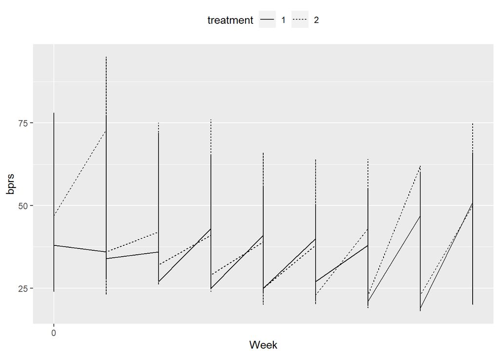

```r
ggplot(BPRSL, aes(x = week, y = bprs, group = treatment)) +
  geom_line(aes(linetype = treatment)) +
  scale_x_continuous(name = "Week", breaks = seq(0, 60, 20)) +
  scale_y_continuous(name = "bprs") +
  theme(legend.position = "top")
```

The two treatments have the same directions but otherwise they behave differently. Week 0 is different even with the direction. Treatment 2 has a higher bprs value on week 0 but both have the same value in the end.

Create a vector of the fitted values, new column fitted, and a plot

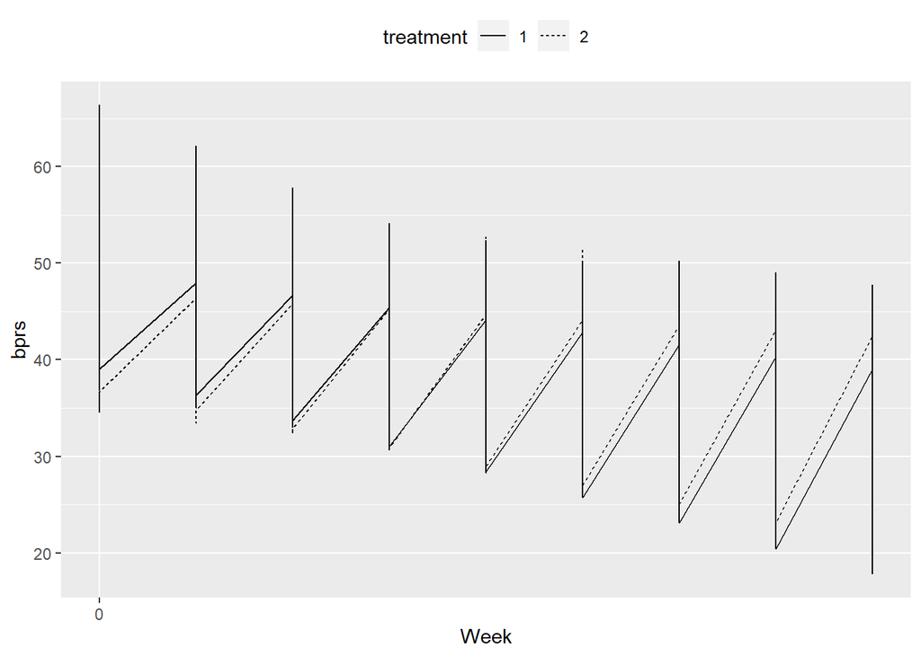

```r
Fitted <- fitted(BPRSL_ref2)


BPRSL <- BPRSL %>%
  mutate(Fitted)

ggplot(BPRSL, aes(x = week, y = Fitted, group = treatment)) +
  geom_line(aes(linetype = treatment)) +
  scale_x_continuous(name = "Week", breaks = seq(0, 60, 20)) +
  scale_y_continuous(name = "bprs") +
  theme(legend.position = "top")
```

Now the two treatments behave more similar. Treatment 2 starts with a lower bprs values but seems to have larger values as the weeks go by.